# Predicting Stock Market Returns

Stock market trading is an application domain with a large potential for data mining. In effect, the existence of an enormous amount of historical data suggests that data mining can provide a competitive advantage over human inspection of these data. On the other hand, there are researchers claiming that the markets adapt so rapidly in terms of price adjustments that there is no space to obtain profits in a consistent way. This is usually known as the efficient markets hypothesis. This theory has been successively replaced by more relaxed versions that leave some space for trading opportunities due to temporary market inefficiencies.

## 0.1 Problem Description and Objectives

The general goal of stock trading is to maintain a portfolio of assets based on buy and sell orders. The long-term objective is to achieve as much profit as possible from these trading actions. In the context of this chapter we will constrain a bit more this general scenario. Namely, we will only “trade” a single security, actually a market index. Given this security and an initial capital, we will try to maximize our profit over a future testing period by means of trading actions (Buy, Sell, Hold). Our trading strategy will use as a basis for decision making the indications provided by the result of a data mining process. This process will consist of trying to predict the future evolution of the index based on a model obtained with historical quotes data. Thus our prediction model will be incorporated in a trading system that generates its decisions based on the predictions of the model. Our overall evaluation criteria will be the performance of this trading system, that is, the profit/loss resulting from the actions of the system as well as some other statistics that are of interest to investors. This means that our main evaluation criteria will be the operational results of applying the knowledge discovered by our data mining process and not the predictive accuracy of the models developed during this process.

```r
library(xts)
library(quantmod)
library(DMwR2)
```

```r
data(GSPC, package="DMwR2")
```

## 0.2 The Available Data

In our case study we will concentrate on trading the S&P 500 market index. Daily data concerning the quotes of this security are freely available in many places, for example, the Yahoo finance site.

```r
head(GSPC)
```

```
##            GSPC.Open GSPC.High GSPC.Low GSPC.Close GSPC.Volume GSPC.Adjusted
## 1970-01-02     92.06     93.54    91.79      93.00     8050000         93.00
## 1970-01-05     93.00     94.25    92.53      93.46    11490000         93.46
## 1970-01-06     93.46     93.81    92.13      92.82    11460000         92.82
## 1970-01-07     92.82     93.38    91.93      92.63    10010000         92.63
## 1970-01-08     92.63     93.47    91.99      92.68    10670000         92.68
## 1970-01-09     92.68     93.25    91.82      92.40     9380000         92.40
```

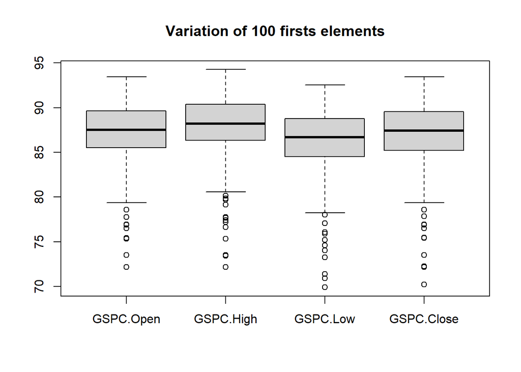

```r
boxplot(GSPC[0:100,0:4], main='Variation of 100 firsts elements')
```

Whichever source you choose to use, the daily stock quotes data includes information regarding the following properties:

- Date of the stock exchange session
- Open price at the beginning of the session (GSPC.Open)
- Highest price during the session (GSPC.High)
- Lowest price (GSPC.Low)
- Closing price of the session (GSPC.Close)
- Volume of transactions (GSPC.Volume)
- Adjusted close price (GSPC.Adjusted). This is basically the closing price adjusted for stock splits, dividends/distributions, and rights offerings.

## 0.3 What to Predict?

Let us assume that if the prices vary more than $p\%$, we consider this worthwhile in terms of trading (e.g., covering transaction costs). In this context, we want our prediction models to forecast whether this margin is attainable in the next $k$ days. Please note that within these $k$ days we can actually observe prices both above and below this percentage. This means that predicting a particular quote for a specific future time $t + k$ might not be the best idea. In effect, what we want is to have a prediction of the overall dynamics of the price in the next $k$ days, and this is not captured by a particular price at a specific time. For instance, the closing price at time $t + k$ may represent a variation much lower than $p\%$, but it could have been preceded by a period of prices representing variations much higher than $p\%$ within the window $t \cdots t + k$. So, what we want in effect is to have a good prediction of the overall tendency of the prices in the next $k$ days.

We will describe a variable, calculated with the quotes data, that can be seen as an indicator (a value) of the tendency in the next $k$ days. The value of this indicator should be related to the confidence we have that the target margin $p$ will be attainable in the next $k$ days. At this stage it is important to note that when we mention a variation of $p\%$, we mean above or below the current price. The idea is that positive variations will lead us to buy, while negative variations will trigger sell actions. The indicator we are proposing resumes the tendency as a single value, positive for upward tendencies, and negative for downward price tendencies.

Let the daily average price be approximated by

$$\bar{P_i} = \frac{C_i + H_i + L_i}{3}$$

where $C_i$, $H_i$ and $L_i$ are the close, high, and low quotes for day $i$, respectively.

Let $V_i$ be the set of $k$ percentage variations (often called arithmetic returns) of today close to the following $k$ days average prices:

$$V_i = \{\frac{\bar{P_{i+j}} - C_i}{C_i}\}_{j=1}^k$$

Our indicator variable is the total sum of the variations in this set whose absolute value is above our target margin $p\%$:

$$T_i = \sum \{v \in V_i:v > p\% \vee v < -p\%\}$$

The general idea of the variable $T$ is to signal $k$-days periods that have several days with average daily prices clearly above the target variation. High positive values of $T$ mean that there are several average daily prices that are $p\%$ higher than today close. Such situations are good indications of potential opportunities to issue a buy order, as we have good expectations that the prices will rise. On the other hand, highly negative values of $T$ suggest sell actions, given the prices will probably decline. Values around zero can be caused by periods with “flat” prices or by conflicting positive and negative variations that cancel each other.

The following function implements this simple indicator:

```r
T.ind <- function(quotes, tgt.margin = 0.025, n.days = 10) {
  v <- apply(HLC(quotes), 1, mean)
  v[1] <- Cl(quotes)[1]

  r <- matrix(NA, ncol = n.days, nrow = NROW(quotes))
  for (x in 1:n.days) r[, x] <- Next(Delt(v, k = x), x)

  x <- apply(r, 1, function(x) sum(x[x > tgt.margin | x < -tgt.margin]))
  if (is.xts(quotes)) xts(x, time(quotes)) else x
}
```

The function starts by obtaining the average price calculated according to Equation before. The function $HLC()$ extracts the High, Low, and Close quotes from a quotes object. We then obtain the returns of the next n.days days with respect to the current close price. The $Next()$ function allows one to shift the values of a time series in time (both forward or backward). The $Delt()$ function can be used to calculate percentage or log returns of a series of prices. Finally, the $T.ind()$ function sums up the large absolute returns, that is, returns above the target variation margin, which we have set by default to $2.5\%$.

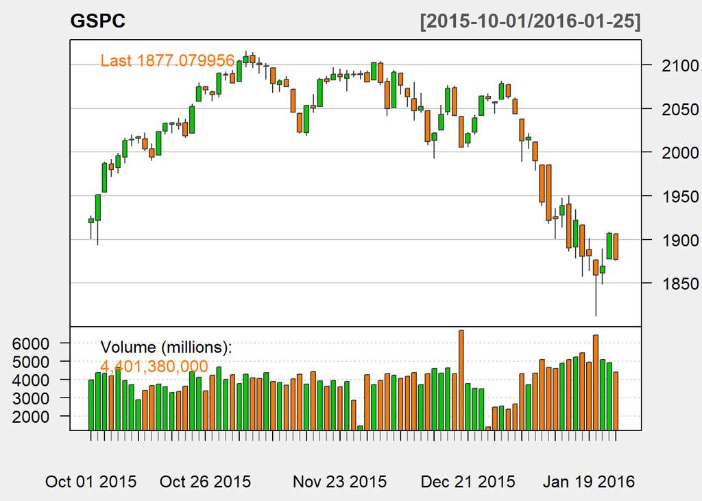

```r
candleChart(GSPC, subset='last 4 months', theme='white')
```

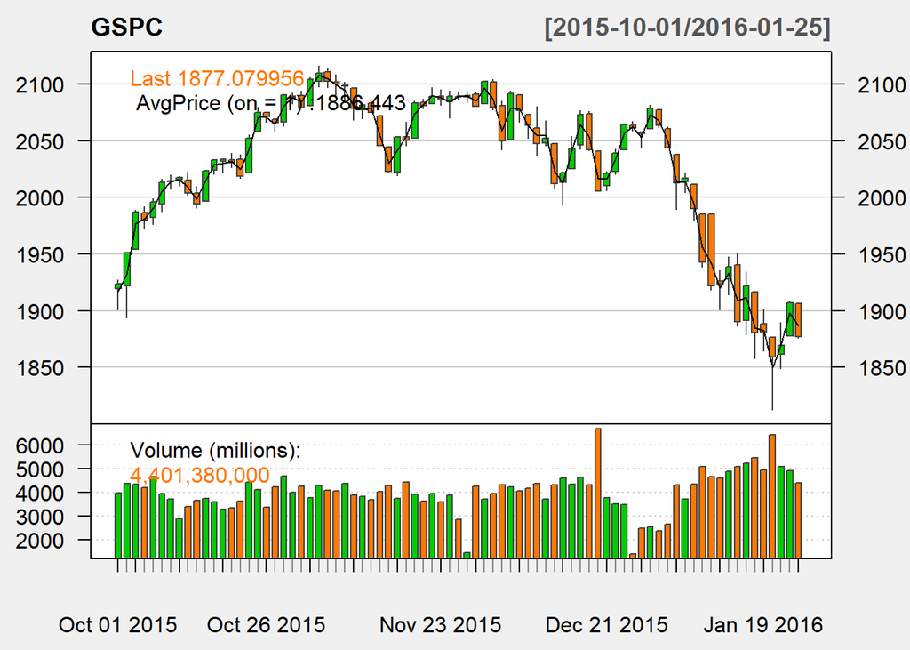

```r
avgPrice <- function(p) apply(HLC(p),1,mean)
addAvgPrice <- newTA(FUN=avgPrice,col=1,legend='AvgPrice')
addT.ind <- newTA(FUN=T.ind,col='red', legend='tgtRet')
addAvgPrice(on=1)
```

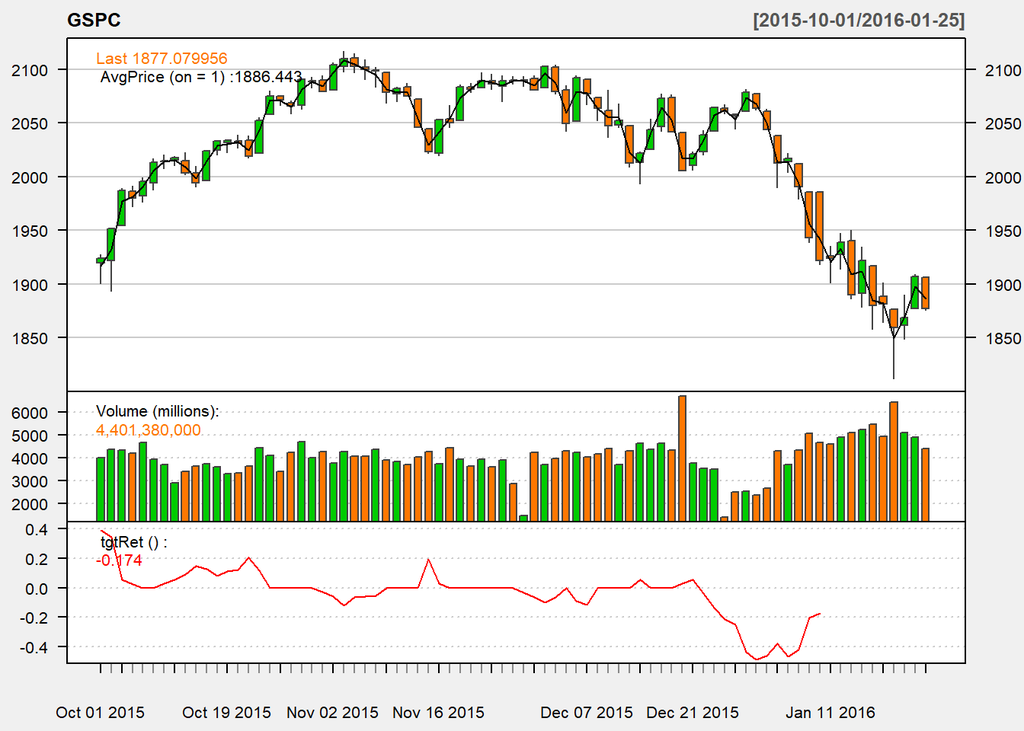

```r
addT.ind()
```

In our approach to this problem we will assume that the correct trading action at time $t$ is related to what our expectations are concerning the evolution of prices in the next $k$ days. Moreover, we will describe this future evolution of the prices by our indicator $T$. The correct trading signal at time $t$ will be “buy” if the T score is higher than a certain threshold, and will be “sell” if the score is below another threshold. In all other cases, the correct signal will be do nothing (i.e., “hold”). In summary, we want to be able to predict the correct signal for time $t$. On historical data we will fill in the correct signal for each day by calculating the respective $T$ scores and using the thresholding method just outlined above.

## 0.4 Which Predictors?

We have defined an indicator $(T)$ that summarizes the behavior of the price time series in the next $k$ days. Our data mining goal will be to predict this behavior. The main assumption behind trying to forecast the future behavior of financial markets is that it is possible to do so by observing the past behavior of the market. More precisely, we are assuming that if in the past a certain behavior $p$ was followed by another behavior $f$, and if that causal chain happened frequently, then it is plausible to assume that this will occur again in the future; and thus if we observe p now, we predict that we will observe $f$ next. We are approximating the future behavior $(f)$, by our indicator $T$. We now have to decide on how we will describe the recent prices pattern ($p$ in the description above). Instead of using again a single indicator to describe these recent dynamics, we will use several indicators, trying to capture different properties of the price time series to facilitate the forecasting task.

```r
library(TTR)
myATR <- function(x) ATR(HLC(x))[,'atr']
mySMI <- function(x) SMI(HLC(x))[, "SMI"]
myADX <- function(x) ADX(HLC(x))[,'ADX']
myAroon <- function(x) aroon(cbind(Hi(x),Lo(x)))$oscillator
myBB <- function(x) BBands(HLC(x))[, "pctB"]
myChaikinVol <- function(x) Delt(chaikinVolatility(cbind(Hi(x),Lo(x))))[, 1]
myCLV <- function(x) EMA(CLV(HLC(x)))[, 1]
myEMV <- function(x) EMV(cbind(Hi(x),Lo(x)),Vo(x))[,2]
myMACD <- function(x) MACD(Cl(x))[,2]
myMFI <- function(x) MFI(HLC(x), Vo(x))
mySAR <- function(x) SAR(cbind(Hi(x),Cl(x))) [,1]
myVolat <- function(x) volatility(OHLC(x),calc="garman")[,1]
```

```r
library(randomForest)
data.model <- specifyModel(T.ind(GSPC) ~
                             Delt(Cl(GSPC),k=1:10)
                           + myATR(GSPC)
                           + mySMI(GSPC)
                           + myADX(GSPC)
                           + myAroon(GSPC)
                           + myBB(GSPC)
                           + myChaikinVol(GSPC)
                           + myCLV(GSPC)
                           + CMO(Cl(GSPC))
                           + EMA(Delt(Cl(GSPC)))
                           + myEMV(GSPC)
                           + myVolat(GSPC)
                           + myMACD(GSPC)
                           + myMFI(GSPC)
                           + RSI(Cl(GSPC))
                           + mySAR(GSPC)
                           + runMean(Cl(GSPC))
                           + runSD(Cl(GSPC)))
```

The code given above starts by specifying and obtaining the data to be used for modeling using the function $specifyModel()$. This function creates a quantmod object that contains the specification of a certain abstract model (described by a formula). This specification may refer to data coming from different types of quantmod data sources, some of which may even not be currently in the memory of the computer. The function will take care of these cases using $getSymbols()$ to obtain the necessary data. This results in a very handy form of specifying and getting the data necessary for your subsequent modeling stages. Moreover, for symbols whose source is the Web, you can later use the obtained object (data.model in our case) as an argument to the function $getModelData()$, to obtain a refresh of the object including any new quotes that may be available at that time. Again, this is quite convenient if you want to maintain a trading system that should be updated with new quotes information.

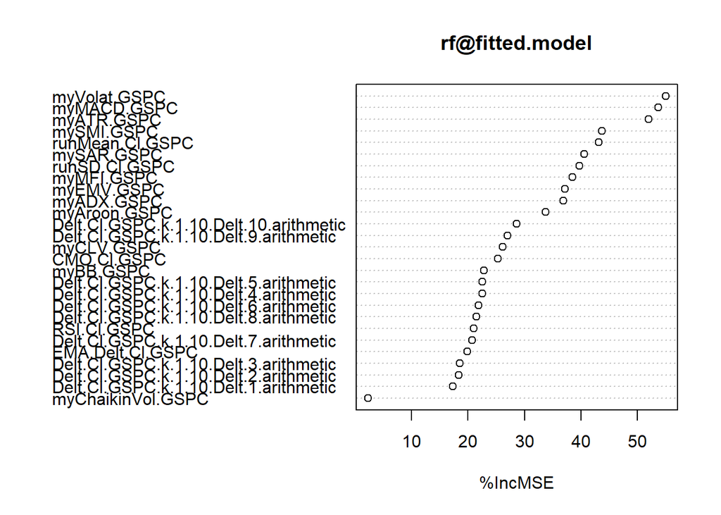

```r
set.seed(1234)
rf <- buildModel(data.model,method='randomForest',
                 training.per=c("1995-01-01","2005-12-30"),
                 ntree=1000,
                 importance=TRUE)

varImpPlot(rf@fitted.model, type = 1)
```

The result of this function call is given in Figure 5.2. The arguments to the varImpPlot() function are the random forest and the score we wish to plot (if omitted both are plotted) - in this case we have selected (with type=1) the percentage increase in the error of the forest. The generic function buildModel() returns the obtained model as a slot (fitted.model) of the quantmod object it produces as a result. At this stage we need to decide on a threshold of the importance score to select only a subset of the features. Looking at the results in the figure and given that this is a simple illustration of the concept of using random forests for selecting features, we will use the value of 30 as the threshold as there seems to be a clear difference in scores of the features above and below this value:

```r
imp <- importance(rf@fitted.model, type = 1)
rownames(imp)[which(imp > 30)]
```

```
##  [1] "myATR.GSPC"      "mySMI.GSPC"      "myADX.GSPC"      "myAroon.GSPC"
##  [5] "myEMV.GSPC"      "myVolat.GSPC"    "myMACD.GSPC"     "myMFI.GSPC"
##  [9] "mySAR.GSPC"      "runMean.Cl.GSPC" "runSD.Cl.GSPC"
```

The function $importance()$ obtains the concrete scores (in this case the first score) for each variable, which we then filter with our threshold to obtain the names of the variables that we will use in our modeling attempts. Using this information we can obtain our final dataset as follows:

```r
data.model <- specifyModel(T.ind(GSPC) ~
                           myATR(GSPC)
                           + mySMI(GSPC)
                           + myADX(GSPC)
                           + myAroon(GSPC)
                           + myEMV(GSPC)
                           + myVolat(GSPC)
                           + myMACD(GSPC)
                           + myMFI(GSPC)
                           + mySAR(GSPC)
                           + runMean(Cl(GSPC))
                           + runSD(Cl(GSPC)))
```

## 0.5 The Prediction Tasks

In the previous section we have obtained a quantmod object (data.model) containing the specification of the data we plan to use with our predictive models. This data has as a target the value of the $T$ indicator and as predictors a series of other variables that resulted from a feature selection process. We have seen in previous section that our real goal is to predict the correct trading signal at any time $t$. How can we do that, given the data we have generated in the previous section? We will explore two paths to obtain predictions for the correct trading signal.

The first alternative is to use the $T$ value as the target variable and try to obtain models that forecast this value using the predictor’s information. This is a multiple regression task similar to the ones we considered before. If we follow this path, we will then have to “translate” our model predictions into trading signals. This means to decide upon the thresholds on the predicted $T$ values that will lead to either of the three possible trading actions. We will carry out this transformation using the following values:

$$\begin{aligned}
signal =
\begin{cases}
\text{sell if $T$ < -0.1}\\
\text{hold if -0.1 $\leq$ $T$ $\leq$ 0.1}\\
\text{buy if $T$ > 0.1}\\
\end{cases}
\end{aligned}$$

The selection of the values $0.1$ and $−0.1$ is purely heuristic and we can also use other thresholds. Still, these values mean that during the $10$-day period used to generate the $T$ values, there were at least four average daily prices that are $2.5\%$ above the current close ($4×0.025 = 0.1$). If you decide to use other values, you should consider that too high absolute values will originate fewer signals, while too small values may lead us to trade on too small variations of the market, thus incurring a larger risk. Function $trading.signals()$, available in the book package, can carry out this transformation of the numeric $T$ values into a factor with three possible values: “s”, “h”, and “b”, for sell, hold and buy actions, respectively.

```r
Tdata.train <- as.data.frame(
  modelData(data.model,
    data.window=c('1970-01-02','2005-12-30')))

Tdata.eval <- na.omit(as.data.frame(
  modelData(data.model,
    data.window=c('2006-01-01','2016-01-25'))))

Tform <- as.formula('T.ind.GSPC ~ .')

buy.thr <- 0.1
sell.thr <- -0.1

Tdata.trainC <- cbind(
  Signal=trading.signals(Tdata.train[["T.ind.GSPC"]],
    buy.thr,sell.thr),
    Tdata.train[,-1])

Tdata.evalC <- cbind(
  Signal=trading.signals(Tdata.eval[["T.ind.GSPC"]],
    buy.thr,sell.thr),
    Tdata.eval[,-1])

TformC <- as.formula("Signal ~ .")
```

## 0.6 Evaluation Criteria

The prediction tasks described in the previous section can be used to obtain models that will output some form of indication regarding the future market direction. This indication will be a number in the case of the regression tasks (the predicted value of $T$), or a direct signal in the case of classification tasks. Even in the case of regression tasks, we have seen that we will cast this number into a signal by a thresholding mechanism. We will describe several trading strategies that use these predicted signals to act on the market, i.e. that will transform these predicted signals into concrete market orders. In this section we will address the question of how to evaluate the signal predictions of our models.We will not consider the evaluation of the numeric predictions of the T indicator.

Due to the way we are using these numeric predictions, this evaluation is a bit irrelevant. One might even question whether it makes sense to have these regression tasks, given that we are only interested in the trading signals. We have decided to maintain these numeric tasks because different trading strategies could take advantage of the numeric predictions, for instance, to decide which amount of money to invest when opening a position. For example, $T$ values much higher than our thresholds for acting ($T > 0.1$ for buying and $T < −0.1$ for selling) could lead to stronger investments.

The evaluation of the signal predictions could be carried out by measuring the error rate, defined as

$$err = \frac{1}{N} \sum_{n=1}^{N} L_{0/1} (y_i,\hat{y_i})$$

One often uses the complement of this measure, known as accuracy, given by $acc = 1−err$. These two statistics basically compare the model predictions to what really happened to the markets in the $k$ future days.

## 0.7 The Prediction Models

Artificial neural networks (ANNs) are frequently used in financial forecasting (e.g., Deboeck, 1994) because of their ability to deal with highly nonlinear problems. The package nnet (Venables and Ripley, 2002) is one of the several packages in R that implements feedforward neural nets. This type of neural network is among the most used and also what we will be applying. ANNs are formed by a set of computing units (the neurons) linked to each other. Each neuron executes two consecutive calculations: a linear combination of its inputs, followed by a nonlinear computation of the result to obtain its output value that is then fed to other neurons in the network. Each of the neuron connections has an associated weight.

Constructing an artificial neural network consists of establishing an architecture for the network and then using an algorithm to find the weights of the connections between the neurons. Feed-forward artificial neural networks have their neurons organized in layers. The first layer contains the input neurons of the network. The training observations of the problem are presented to the network through these input neurons. The final layer contains the predictions of the neural network for any case presented at its input neurons. In between, we usually have one or more “hidden” layers of neurons. The weight updating algorithms, such as the back-propagation method, try to obtain the connection weights that optimize a certain error criterion, that is, trying to ensure that the network outputs are in accordance with the cases presented to the model. This is accomplished by an iterative process of presenting several times the training cases at the input nodes of the network, and after obtaining the prediction of the network at the output nodes and calculating the respective prediction error, updating the weights in the network to try to improve its prediction error. This iterative process is repeated until some convergence criterion is met.

```r
library(nnet)
## The first column is the target variable
norm.data <- data.frame(T.ind.GSPC=Tdata.train[[1]],scale(Tdata.train[,-1]))
nn <- nnet(Tform, norm.data[1:1000, ],
           size = 5,
           decay = 0.01,
           maxit = 1000,
           linout = TRUE,
           trace = FALSE)
preds <- predict(nn, norm.data[1001:2000, ])
```

Namely, the parameter size allows us to specify how many nodes the hidden layer will have. There is no magic recipe on which value to use here. One usually tries several values to observe the network behavior. Still, one frequently uses a value smaller than the number of predictors of the problem. The parameter decay controls the weight updating rate of the back-propagation algorithm. Again, trial and error is your best friend here. Finally, the parameter $maxit$ controls the maximum number of iterations the weight convergence process is allowed to use, while the $linout=TRUE$ setting tells the function that we are handling a regression problem. The $trace=FALSE$ is used to avoid some of the output of the function regarding the optimization process.

```r
sigs.nn <- trading.signals(preds,0.1,-0.1)
true.sigs <- trading.signals(Tdata.train[1001:2000, "T.ind.GSPC"], 0.1, -0.1)
sigs.PR(sigs.nn,true.sigs)
```

```
##     precision    recall
## s   0.2777778 0.1704545
## b   0.2296651 0.2981366
## s+b 0.2460568 0.2314540
```

Function $trading.signals()$ transforms numeric predictions into signals, given the buy and sell thresholds, respectively. The function $sigs.PR()$, also from our book package, obtains a matrix with the precision and recall scores of the two types of events, and overall. These scores show that the performance of the ANN is not brilliant. In effect, you get rather low precision scores, and also not so interesting recall values. The latter are not so serious as they basically mean lost opportunities and not costs. On the contrary, low precision scores mean that the model gave wrong signals rather frequently. If these signals are used for trading, this may lead to serious losses of money.

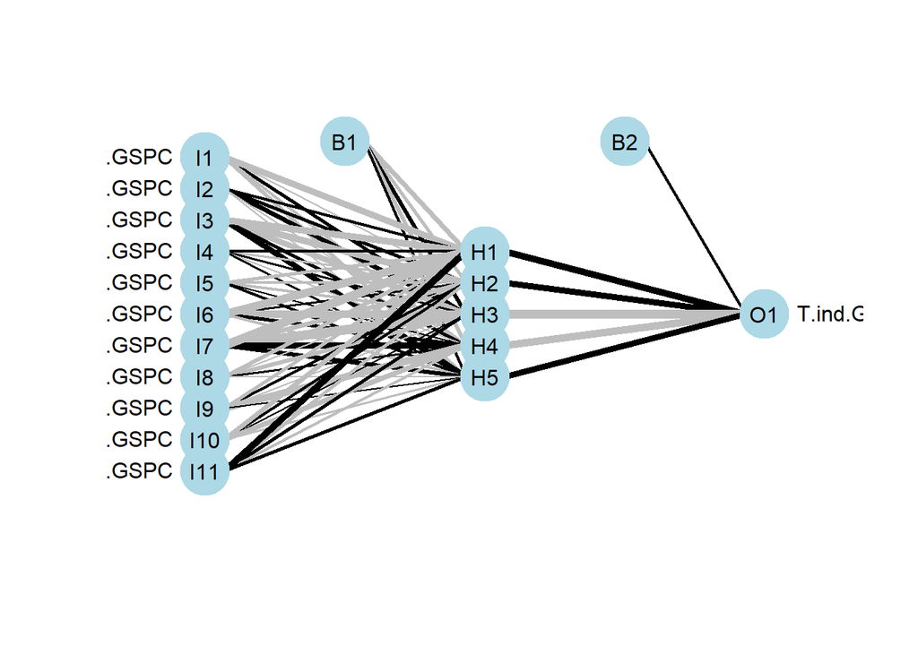

```r
library(NeuralNetTools)
plotnet(nn)
```

ANNs can also be used for classification tasks. For these problems the main difference in terms of network topology is that instead of a single output unit, we will have as many output units as there are values of the target variable (sometimes known as the classes). Each of these output units will produce a probability estimate of the respective class value. This means that for each test case, an ANN can produce a set of probability values, one for each possible class value.